# Results: Program 1

The CONTENTS Procedure

| Data Set Name | WORK.VALIDATION | Observations | 110 |
| --- | --- | --- | --- |
| Member Type | DATA | Variables | 109 |
| Engine | V9 | Indexes | 0 |
| Created | 09/06/2022 12:25:50 | Observation Length | 832 |
| Last Modified | 09/06/2022 12:25:50 | Deleted Observations | 0 |
| Protection |  | Compressed | NO |
| Data Set Type |  | Sorted | NO |
| Label |  |  |  |
| Data Representation | SOLARIS_X86_64, LINUX_X86_64, ALPHA_TRU64, LINUX_IA64 |  |  |
| Encoding | utf-8 Unicode (UTF-8) |  |  |

[output not shown]

| Alphabetic List of Variables and Attributes # | Alphabetic List of Variables and Attributes Variable | Alphabetic List of Variables and Attributes Type | Alphabetic List of Variables and Attributes Len | Alphabetic List of Variables and Attributes Format | Alphabetic List of Variables and Attributes Informat |
| --- | --- | --- | --- | --- | --- |
| 63 | ...63 | Char | 1 | $1. | $1. |
| 93 | ...93 | Char | 1 | $1. | $1. |
| 91 | 8-isoprostane (pg/mg creat) | Num | 8 | BEST12. | BEST32. |
| 28 | ACE/ARB | Num | 8 | BEST12. | BEST32. |
| 2 | Age | Num | 8 | BEST12. | BEST32. |
| 16 | Arrhythmia | Num | 8 | BEST12. | BEST32. |
| 17 | Atrial fibrillation | Num | 8 | BEST12. | BEST32. |
| 34 | BMI (kg/m2) | Num | 8 | BEST12. | BEST32. |
| 83 | BNP (pg/mL) | Num | 8 | BEST12. | BEST32. |
| 84 | BNP >150 | Num | 8 | BEST12. | BEST32. |
| 35 | BSA (m2) | Num | 8 | BEST12. | BEST32. |
| 80 | BUN (mg/dL) | Num | 8 | BEST12. | BEST32. |
| 29 | Beta Blocker | Num | 8 | BEST12. | BEST32. |
| 14 | CAD | Num | 8 | BEST12. | BEST32. |
| 49 | CI (L/min/m2) | Num | 8 | BEST12. | BEST32. |
| 48 | CO (L/min) | Num | 8 | BEST12. | BEST32. |
| 50 | CPO (W) | Num | 8 | BEST12. | BEST32. |
| 40 | Cardiac Rhythm | Num | 8 | BEST12. | BEST32. |
| 22 | Cardiac Transplantation | Num | 8 | BEST12. | BEST32. |
| 1 | Cohort Number | Num | 8 | BEST12. | BEST32. |
| 81 | Creatinine (mg/dL) | Num | 8 | BEST12. | BEST32. |
| 37 | DBP (mmHg) | Num | 8 | BEST12. | BEST32. |
| 99 | Date Assessment | Num | 8 | B8601DZ35. | B8601DZ35. |
| 94 | Date of Cath | Num | 8 | B8601DZ35. | B8601DZ35. |
| 95 | Date of LVAD | Char | 1 | $1. | $1. |
| 100 | Date of Last Known Clincial Stat | Num | 8 | B8601DZ35. | B8601DZ35. |
| 97 | Date of TX | Char | 1 | $1. | $1. |
| 103 | Date of death | Num | 8 | B8601DZ35. | B8601DZ35. |
| 102 | Dead | Num | 8 | BEST12. | BEST32. |
| 12 | Diabetes | Num | 8 | BEST12. | BEST32. |

[output cut: 79 more lines]

The LIFETEST Procedure

Stratum 1: TBX_group = 0

| Product-Limit Survival Estimates dead_days | Product-Limit Survival Estimates | Product-Limit Survival Estimates Survival | Product-Limit Survival Estimates Failure | Product-Limit Survival Estimates Survival Standard Error | Product-Limit Survival Estimates Number Failed | Product-Limit Survival Estimates Number Left |
| --- | --- | --- | --- | --- | --- | --- |
| 0.00 |  | 1.0000 | 0 | 0 | 0 | 21 |
| 37.00 |  | 0.9524 | 0.0476 | 0.0465 | 1 | 20 |
| 152.00 |  | 0.9048 | 0.0952 | 0.0641 | 2 | 19 |
| 197.00 |  | . | . | . | 3 | 18 |
| 197.00 |  | 0.8095 | 0.1905 | 0.0857 | 4 | 17 |
| 219.00 |  | 0.7619 | 0.2381 | 0.0929 | 5 | 16 |
| 259.00 |  | 0.7143 | 0.2857 | 0.0986 | 6 | 15 |
| 286.00 |  | 0.6667 | 0.3333 | 0.1029 | 7 | 14 |
| 416.00 |  | 0.6190 | 0.3810 | 0.1060 | 8 | 13 |
| 481.00 |  | 0.5714 | 0.4286 | 0.1080 | 9 | 12 |
| 539.00 |  | 0.5238 | 0.4762 | 0.1090 | 10 | 11 |
| 634.00 |  | 0.4762 | 0.5238 | 0.1090 | 11 | 10 |
| 783.00 |  | 0.4286 | 0.5714 | 0.1080 | 12 | 9 |
| 1198.00 |  | 0.3810 | 0.6190 | 0.1060 | 13 | 8 |
| 1361.00 |  | 0.3333 | 0.6667 | 0.1029 | 14 | 7 |
| 1386.00 |  | 0.2857 | 0.7143 | 0.0986 | 15 | 6 |
| 1643.00 |  | 0.2381 | 0.7619 | 0.0929 | 16 | 5 |
| 2096.00 |  | 0.1905 | 0.8095 | 0.0857 | 17 | 4 |
| 2355.00 |  | 0.1429 | 0.8571 | 0.0764 | 18 | 3 |
| 2445.00 |  | 0.0952 | 0.9048 | 0.0641 | 19 | 2 |
| 3074.00 |  | 0.0476 | 0.9524 | 0.0465 | 20 | 1 |
| 3633.00 |  | 0 | 1.0000 | . | 21 | 0 |

Summary Statistics for Time Variable dead_days

| Quartile Estimates Percent | Quartile Estimates Point Estimate | Quartile Estimates 95% Confidence Interval Transform | Quartile Estimates 95% Confidence Interval [Lower | Quartile Estimates 95% Confidence Interval Upper) |
| --- | --- | --- | --- | --- |
| 75 | 1643.00 | LOGLOG | 783.00 | 3074.00 |
| 50 | 634.00 | LOGLOG | 259.00 | 1386.00 |
| 25 | 259.00 | LOGLOG | 37.00 | 481.00 |

| Mean | Standard Error |
| --- | --- |
| 1113.86 | 231.08 |

The LIFETEST Procedure

Stratum 2: TBX_group = 1

| Product-Limit Survival Estimates dead_days | Product-Limit Survival Estimates | Product-Limit Survival Estimates Survival | Product-Limit Survival Estimates Failure | Product-Limit Survival Estimates Survival Standard Error | Product-Limit Survival Estimates Number Failed | Product-Limit Survival Estimates Number Left |
| --- | --- | --- | --- | --- | --- | --- |
| 0.00 |  | 1.0000 | 0 | 0 | 0 | 26 |
| 22.00 |  | 0.9615 | 0.0385 | 0.0377 | 1 | 25 |
| 46.00 |  | 0.9231 | 0.0769 | 0.0523 | 2 | 24 |
| 53.00 |  | 0.8846 | 0.1154 | 0.0627 | 3 | 23 |
| 86.00 |  | 0.8462 | 0.1538 | 0.0708 | 4 | 22 |
| 137.00 |  | 0.8077 | 0.1923 | 0.0773 | 5 | 21 |
| 153.00 |  | 0.7692 | 0.2308 | 0.0826 | 6 | 20 |
| 161.00 |  | 0.7308 | 0.2692 | 0.0870 | 7 | 19 |
| 220.00 |  | 0.6923 | 0.3077 | 0.0905 | 8 | 18 |
| 322.00 |  | 0.6538 | 0.3462 | 0.0933 | 9 | 17 |
| 337.00 |  | 0.6154 | 0.3846 | 0.0954 | 10 | 16 |
| 342.00 |  | 0.5769 | 0.4231 | 0.0969 | 11 | 15 |
| 526.00 |  | 0.5385 | 0.4615 | 0.0978 | 12 | 14 |
| 528.00 |  | 0.5000 | 0.5000 | 0.0981 | 13 | 13 |
| 551.00 |  | 0.4615 | 0.5385 | 0.0978 | 14 | 12 |
| 555.00 |  | 0.4231 | 0.5769 | 0.0969 | 15 | 11 |
| 762.00 |  | 0.3846 | 0.6154 | 0.0954 | 16 | 10 |
| 793.00 |  | 0.3462 | 0.6538 | 0.0933 | 17 | 9 |
| 804.00 |  | 0.3077 | 0.6923 | 0.0905 | 18 | 8 |
| 992.00 |  | 0.2692 | 0.7308 | 0.0870 | 19 | 7 |
| 1168.00 |  | 0.2308 | 0.7692 | 0.0826 | 20 | 6 |
| 1185.00 |  | 0.1923 | 0.8077 | 0.0773 | 21 | 5 |
| 1382.00 |  | 0.1538 | 0.8462 | 0.0708 | 22 | 4 |
| 1754.00 |  | 0.1154 | 0.8846 | 0.0627 | 23 | 3 |
| 2076.00 |  | 0.0769 | 0.9231 | 0.0523 | 24 | 2 |
| 2573.00 |  | 0.0385 | 0.9615 | 0.0377 | 25 | 1 |
| 3979.00 |  | 0 | 1.0000 | . | 26 | 0 |

Summary Statistics for Time Variable dead_days

| Quartile Estimates Percent | Quartile Estimates Point Estimate | Quartile Estimates 95% Confidence Interval Transform | Quartile Estimates 95% Confidence Interval [Lower | Quartile Estimates 95% Confidence Interval Upper) |
| --- | --- | --- | --- | --- |
| 75 | 1168.00 | LOGLOG | 555.00 | 2076.00 |
| 50 | 539.50 | LOGLOG | 220.00 | 804.00 |
| 25 | 161.00 | LOGLOG | 46.00 | 342.00 |

| Mean | Standard Error |
| --- | --- |
| 827.19 | 180.59 |

| Summary of the Number of Censored and Uncensored Values Stratum | Summary of the Number of Censored and Uncensored Values TBX_group | Summary of the Number of Censored and Uncensored Values Total | Summary of the Number of Censored and Uncensored Values Failed | Summary of the Number of Censored and Uncensored Values Censored | Summary of the Number of Censored and Uncensored Values Percent Censored |
| --- | --- | --- | --- | --- | --- |
| 1 | 0 | 21 | 21 | 0 | 0.00 |
| 2 | 1 | 26 | 26 | 0 | 0.00 |
| Total |  | 47 | 47 | 0 | 0.00 |

Note:63 observations with invalid time, censoring, or strata values were deleted.

The LIFETEST Procedure

Testing Homogeneity of Survival Curves for dead_days over Strata

| Rank Statistics TBX_group | Rank Statistics Log-Rank | Rank Statistics Wilcoxon |
| --- | --- | --- |
| 0 | -2.7214 | -88.000 |
| 1 | 2.7214 | 88.000 |

| Covariance Matrix for the Log-Rank Statistics TBX_group | Covariance Matrix for the Log-Rank Statistics 0 | Covariance Matrix for the Log-Rank Statistics 1 |
| --- | --- | --- |
| 0 | 11.2368 | -11.2368 |
| 1 | -11.2368 | 11.2368 |

| Covariance Matrix for the Wilcoxon Statistics TBX_group | Covariance Matrix for the Wilcoxon Statistics 0 | Covariance Matrix for the Wilcoxon Statistics 1 |
| --- | --- | --- |
| 0 | 8864.49 | -8864.49 |
| 1 | -8864.49 | 8864.49 |

| Test of Equality over Strata Test | Test of Equality over Strata Chi-Square | Test of Equality over Strata DF | Test of Equality over Strata Pr > Chi-Square |
| --- | --- | --- | --- |
| Log-Rank | 0.6591 | 1 | 0.4169 |
| Wilcoxon | 0.8736 | 1 | 0.3500 |
| -2Log(LR) | 1.0356 | 1 | 0.3088 |

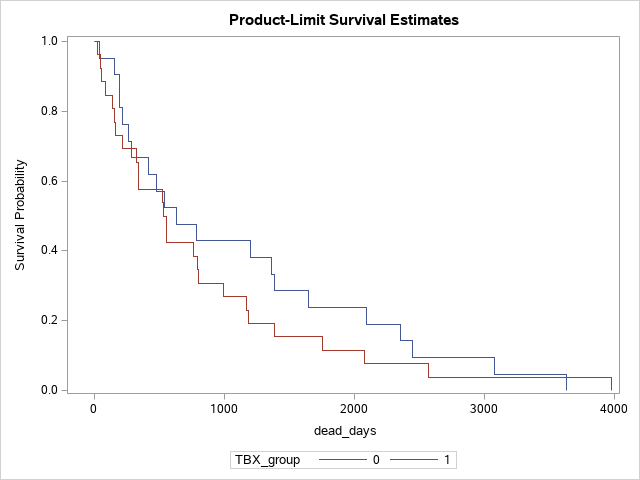

The LIFETEST Procedure

Stratum 1: TBX_group = 0

| Product-Limit Survival Estimates event_free | Product-Limit Survival Estimates | Product-Limit Survival Estimates Survival | Product-Limit Survival Estimates Failure | Product-Limit Survival Estimates Survival Standard Error | Product-Limit Survival Estimates Number Failed | Product-Limit Survival Estimates Number Left |
| --- | --- | --- | --- | --- | --- | --- |
| 0.00 |  | 1.0000 | 0 | 0 | 0 | 57 |
| 10.00 |  | 0.9825 | 0.0175 | 0.0174 | 1 | 56 |
| 11.00 |  | 0.9649 | 0.0351 | 0.0244 | 2 | 55 |
| 16.00 |  | 0.9474 | 0.0526 | 0.0296 | 3 | 54 |
| 37.00 |  | 0.9298 | 0.0702 | 0.0338 | 4 | 53 |
| 134.00 |  | 0.9123 | 0.0877 | 0.0375 | 5 | 52 |
| 152.00 |  | 0.8947 | 0.1053 | 0.0406 | 6 | 51 |
| 197.00 |  | . | . | . | 7 | 50 |
| 197.00 |  | 0.8596 | 0.1404 | 0.0460 | 8 | 49 |
| 259.00 |  | 0.8421 | 0.1579 | 0.0483 | 9 | 48 |
| 286.00 |  | 0.8246 | 0.1754 | 0.0504 | 10 | 47 |
| 416.00 |  | 0.8070 | 0.1930 | 0.0523 | 11 | 46 |
| 481.00 |  | 0.7895 | 0.2105 | 0.0540 | 12 | 45 |
| 539.00 |  | 0.7719 | 0.2281 | 0.0556 | 13 | 44 |
| 555.00 | * | . | . | . | 13 | 43 |
| 580.00 | * | . | . | . | 13 | 42 |
| 605.00 | * | . | . | . | 13 | 41 |
| 634.00 |  | 0.7531 | 0.2469 | 0.0573 | 14 | 40 |
| 689.00 | * | . | . | . | 14 | 39 |
| 783.00 |  | 0.7338 | 0.2662 | 0.0590 | 15 | 38 |
| 819.00 | * | . | . | . | 15 | 37 |
| 821.00 | * | . | . | . | 15 | 36 |
| 827.00 | * | . | . | . | 15 | 35 |
| 846.00 | * | . | . | . | 15 | 34 |
| 862.00 | * | . | . | . | 15 | 33 |
| 887.00 | * | . | . | . | 15 | 32 |
| 906.00 | * | . | . | . | 15 | 31 |
| 907.00 | * | . | . | . | 15 | 30 |
| 943.00 | * | . | . | . | 15 | 29 |
| 954.00 | * | . | . | . | 15 | 28 |
| 964.00 | * | . | . | . | 15 | 27 |
| 973.00 | * | . | . | . | 15 | 26 |
| 1000.00 | * | . | . | . | 15 | 25 |
| 1019.00 | * | . | . | . | 15 | 24 |
| 1024.00 | * | . | . | . | 15 | 23 |
| 1059.00 | * | . | . | . | 15 | 22 |
| 1064.00 | * | . | . | . | 15 | 21 |
| 1159.00 | * | . | . | . | 15 | 20 |
| 1198.00 |  | 0.6971 | 0.3029 | 0.0665 | 16 | 19 |
| 1361.00 |  | 0.6604 | 0.3396 | 0.0724 | 17 | 18 |
| 1386.00 |  | 0.6237 | 0.3763 | 0.0771 | 18 | 17 |
| 1511.00 |  | 0.5870 | 0.4130 | 0.0808 | 19 | 16 |
| 1643.00 |  | 0.5503 | 0.4497 | 0.0837 | 20 | 15 |
| 2024.00 | * | . | . | . | 20 | 14 |
| 2096.00 |  | 0.5110 | 0.4890 | 0.0865 | 21 | 13 |
| 2355.00 |  | 0.4717 | 0.5283 | 0.0883 | 22 | 12 |
| 3074.00 |  | 0.4324 | 0.5676 | 0.0893 | 23 | 11 |
| 3358.00 | * | . | . | . | 23 | 10 |
| 3478.00 | * | . | . | . | 23 | 9 |
| 3563.00 | * | . | . | . | 23 | 8 |
| 3633.00 |  | 0.3784 | 0.6216 | 0.0930 | 24 | 7 |
| 3723.00 | * | . | . | . | 24 | 6 |
| 3786.00 | * | . | . | . | 24 | 5 |
| 3861.00 | * | . | . | . | 24 | 4 |
| 3898.00 | * | . | . | . | 24 | 3 |
| 3991.00 | * | . | . | . | 24 | 2 |
| 3993.00 | * | . | . | . | 24 | 1 |
| 4008.00 | * | . | . | . | 24 | 0 |

Note:The marked survival times are censored observations.

Summary Statistics for Time Variable event_free

| Quartile Estimates Percent | Quartile Estimates Point Estimate | Quartile Estimates 95% Confidence Interval Transform | Quartile Estimates 95% Confidence Interval [Lower | Quartile Estimates 95% Confidence Interval Upper) |
| --- | --- | --- | --- | --- |
| 75 | . | LOGLOG | 3633.00 | . |
| 50 | 2355.00 | LOGLOG | 1361.00 | . |
| 25 | 783.00 | LOGLOG | 197.00 | 1511.00 |

| Mean | Standard Error |
| --- | --- |
| 2202.27 | 226.55 |

Note:The mean survival time and its standard error were underestimated because the largest observation was censored and the estimation was restricted to the largest event time.

The LIFETEST Procedure

Stratum 2: TBX_group = 1

| Product-Limit Survival Estimates event_free | Product-Limit Survival Estimates | Product-Limit Survival Estimates Survival | Product-Limit Survival Estimates Failure | Product-Limit Survival Estimates Survival Standard Error | Product-Limit Survival Estimates Number Failed | Product-Limit Survival Estimates Number Left |
| --- | --- | --- | --- | --- | --- | --- |
| 0.00 |  | 1.0000 | 0 | 0 | 0 | 48 |
| 2.00 |  | 0.9792 | 0.0208 | 0.0206 | 1 | 47 |
| 6.00 |  | 0.9583 | 0.0417 | 0.0288 | 2 | 46 |
| 21.00 |  | 0.9375 | 0.0625 | 0.0349 | 3 | 45 |
| 22.00 |  | 0.9167 | 0.0833 | 0.0399 | 4 | 44 |
| 46.00 |  | 0.8958 | 0.1042 | 0.0441 | 5 | 43 |
| 53.00 |  | 0.8750 | 0.1250 | 0.0477 | 6 | 42 |
| 86.00 |  | 0.8542 | 0.1458 | 0.0509 | 7 | 41 |
| 137.00 |  | 0.8333 | 0.1667 | 0.0538 | 8 | 40 |
| 153.00 |  | 0.8125 | 0.1875 | 0.0563 | 9 | 39 |
| 161.00 |  | 0.7917 | 0.2083 | 0.0586 | 10 | 38 |
| 220.00 |  | 0.7708 | 0.2292 | 0.0607 | 11 | 37 |
| 322.00 |  | 0.7500 | 0.2500 | 0.0625 | 12 | 36 |
| 337.00 |  | 0.7292 | 0.2708 | 0.0641 | 13 | 35 |
| 342.00 |  | 0.7083 | 0.2917 | 0.0656 | 14 | 34 |
| 502.00 | * | . | . | . | 14 | 33 |
| 526.00 |  | 0.6869 | 0.3131 | 0.0670 | 15 | 32 |
| 528.00 |  | 0.6654 | 0.3346 | 0.0683 | 16 | 31 |
| 551.00 |  | 0.6439 | 0.3561 | 0.0694 | 17 | 30 |
| 555.00 |  | 0.6225 | 0.3775 | 0.0703 | 18 | 29 |
| 586.00 | * | . | . | . | 18 | 28 |
| 679.00 | * | . | . | . | 18 | 27 |
| 762.00 |  | 0.5994 | 0.4006 | 0.0714 | 19 | 26 |
| 793.00 |  | 0.5764 | 0.4236 | 0.0723 | 20 | 25 |
| 804.00 |  | 0.5533 | 0.4467 | 0.0730 | 21 | 24 |
| 847.00 | * | . | . | . | 21 | 23 |
| 870.00 | * | . | . | . | 21 | 22 |
| 875.00 | * | . | . | . | 21 | 21 |
| 883.00 | * | . | . | . | 21 | 20 |
| 895.00 | * | . | . | . | 21 | 19 |
| 903.00 | * | . | . | . | 21 | 18 |
| 972.00 | * | . | . | . | 21 | 17 |
| 992.00 |  | 0.5208 | 0.4792 | 0.0756 | 22 | 16 |
| 1016.00 | * | . | . | . | 22 | 15 |
| 1168.00 |  | 0.4860 | 0.5140 | 0.0781 | 23 | 14 |
| 1185.00 |  | 0.4513 | 0.5487 | 0.0799 | 24 | 13 |
| 1382.00 |  | 0.4166 | 0.5834 | 0.0809 | 25 | 12 |
| 1754.00 |  | 0.3819 | 0.6181 | 0.0813 | 26 | 11 |
| 2076.00 |  | 0.3472 | 0.6528 | 0.0810 | 27 | 10 |
| 2573.00 |  | 0.3125 | 0.6875 | 0.0800 | 28 | 9 |
| 3667.00 | * | . | . | . | 28 | 8 |
| 3756.00 | * | . | . | . | 28 | 7 |
| 3812.00 | * | . | . | . | 28 | 6 |
| 3892.00 | * | . | . | . | 28 | 5 |
| 3899.00 | * | . | . | . | 28 | 4 |
| 3979.00 |  | 0.2343 | 0.7657 | 0.0904 | 29 | 3 |
| 3999.00 | * | . | . | . | 29 | 2 |
| 3999.00 | * | . | . | . | 29 | 1 |
| 4003.00 | * | . | . | . | 29 | 0 |

Note:The marked survival times are censored observations.

Summary Statistics for Time Variable event_free

| Quartile Estimates Percent | Quartile Estimates Point Estimate | Quartile Estimates 95% Confidence Interval Transform | Quartile Estimates 95% Confidence Interval [Lower | Quartile Estimates 95% Confidence Interval Upper) |
| --- | --- | --- | --- | --- |
| 75 | 3979.00 | LOGLOG | 1754.00 | . |
| 50 | 1168.00 | LOGLOG | 551.00 | 2573.00 |
| 25 | 329.50 | LOGLOG | 53.00 | 555.00 |

| Mean | Standard Error |
| --- | --- |
| 1768.02 | 261.40 |

Note:The mean survival time and its standard error were underestimated because the largest observation was censored and the estimation was restricted to the largest event time.

| Summary of the Number of Censored and Uncensored Values Stratum | Summary of the Number of Censored and Uncensored Values TBX_group | Summary of the Number of Censored and Uncensored Values Total | Summary of the Number of Censored and Uncensored Values Failed | Summary of the Number of Censored and Uncensored Values Censored | Summary of the Number of Censored and Uncensored Values Percent Censored |
| --- | --- | --- | --- | --- | --- |
| 1 | 0 | 57 | 24 | 33 | 57.89 |
| 2 | 1 | 48 | 29 | 19 | 39.58 |
| Total |  | 105 | 53 | 52 | 49.52 |

Note:5 observations with invalid time, censoring, or strata values were deleted.

The LIFETEST Procedure

Testing Homogeneity of Survival Curves for event_free over Strata

| Rank Statistics TBX_group | Rank Statistics Log-Rank | Rank Statistics Wilcoxon |
| --- | --- | --- |
| 0 | -6.0433 | -480.00 |
| 1 | 6.0433 | 480.00 |

| Covariance Matrix for the Log-Rank Statistics TBX_group | Covariance Matrix for the Log-Rank Statistics 0 | Covariance Matrix for the Log-Rank Statistics 1 |
| --- | --- | --- |
| 0 | 12.9611 | -12.9611 |
| 1 | -12.9611 | 12.9611 |

| Covariance Matrix for the Wilcoxon Statistics TBX_group | Covariance Matrix for the Wilcoxon Statistics 0 | Covariance Matrix for the Wilcoxon Statistics 1 |
| --- | --- | --- |
| 0 | 70653.0 | -70653.0 |
| 1 | -70653.0 | 70653.0 |

| Test of Equality over Strata Test | Test of Equality over Strata Chi-Square | Test of Equality over Strata DF | Test of Equality over Strata Pr > Chi-Square |
| --- | --- | --- | --- |
| Log-Rank | 2.8178 | 1 | 0.0932 |
| Wilcoxon | 3.2610 | 1 | 0.0709 |
| -2Log(LR) | 2.9173 | 1 | 0.0876 |

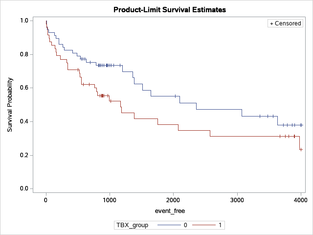

The LIFETEST Procedure

Stratum 1: EGFR_group = 0

| Product-Limit Survival Estimates dead_days | Product-Limit Survival Estimates | Product-Limit Survival Estimates Survival | Product-Limit Survival Estimates Failure | Product-Limit Survival Estimates Survival Standard Error | Product-Limit Survival Estimates Number Failed | Product-Limit Survival Estimates Number Left |
| --- | --- | --- | --- | --- | --- | --- |
| 0.00 |  | 1.0000 | 0 | 0 | 0 | 10 |
| 197.00 |  | 0.9000 | 0.1000 | 0.0949 | 1 | 9 |
| 219.00 |  | 0.8000 | 0.2000 | 0.1265 | 2 | 8 |
| 481.00 |  | 0.7000 | 0.3000 | 0.1449 | 3 | 7 |
| 634.00 |  | 0.6000 | 0.4000 | 0.1549 | 4 | 6 |
| 1361.00 |  | 0.5000 | 0.5000 | 0.1581 | 5 | 5 |
| 1386.00 |  | 0.4000 | 0.6000 | 0.1549 | 6 | 4 |
| 1643.00 |  | 0.3000 | 0.7000 | 0.1449 | 7 | 3 |
| 2355.00 |  | 0.2000 | 0.8000 | 0.1265 | 8 | 2 |
| 3074.00 |  | 0.1000 | 0.9000 | 0.0949 | 9 | 1 |
| 3633.00 |  | 0 | 1.0000 | . | 10 | 0 |

Summary Statistics for Time Variable dead_days

| Quartile Estimates Percent | Quartile Estimates Point Estimate | Quartile Estimates 95% Confidence Interval Transform | Quartile Estimates 95% Confidence Interval [Lower | Quartile Estimates 95% Confidence Interval Upper) |
| --- | --- | --- | --- | --- |
| 75 | 2355.00 | LOGLOG | 1361.00 | . |
| 50 | 1373.50 | LOGLOG | 197.00 | 2355.00 |
| 25 | 481.00 | LOGLOG | 197.00 | 1386.00 |

| Mean | Standard Error |
| --- | --- |
| 1498.30 | 379.15 |

The LIFETEST Procedure

Stratum 2: EGFR_group = 1

| Product-Limit Survival Estimates dead_days | Product-Limit Survival Estimates | Product-Limit Survival Estimates Survival | Product-Limit Survival Estimates Failure | Product-Limit Survival Estimates Survival Standard Error | Product-Limit Survival Estimates Number Failed | Product-Limit Survival Estimates Number Left |
| --- | --- | --- | --- | --- | --- | --- |
| 0.00 |  | 1.0000 | 0 | 0 | 0 | 37 |
| 22.00 |  | 0.9730 | 0.0270 | 0.0267 | 1 | 36 |
| 37.00 |  | 0.9459 | 0.0541 | 0.0372 | 2 | 35 |
| 46.00 |  | 0.9189 | 0.0811 | 0.0449 | 3 | 34 |
| 53.00 |  | 0.8919 | 0.1081 | 0.0510 | 4 | 33 |
| 86.00 |  | 0.8649 | 0.1351 | 0.0562 | 5 | 32 |
| 137.00 |  | 0.8378 | 0.1622 | 0.0606 | 6 | 31 |
| 152.00 |  | 0.8108 | 0.1892 | 0.0644 | 7 | 30 |
| 153.00 |  | 0.7838 | 0.2162 | 0.0677 | 8 | 29 |
| 161.00 |  | 0.7568 | 0.2432 | 0.0705 | 9 | 28 |
| 197.00 |  | 0.7297 | 0.2703 | 0.0730 | 10 | 27 |
| 220.00 |  | 0.7027 | 0.2973 | 0.0751 | 11 | 26 |
| 259.00 |  | 0.6757 | 0.3243 | 0.0770 | 12 | 25 |
| 286.00 |  | 0.6486 | 0.3514 | 0.0785 | 13 | 24 |
| 322.00 |  | 0.6216 | 0.3784 | 0.0797 | 14 | 23 |
| 337.00 |  | 0.5946 | 0.4054 | 0.0807 | 15 | 22 |
| 342.00 |  | 0.5676 | 0.4324 | 0.0814 | 16 | 21 |
| 416.00 |  | 0.5405 | 0.4595 | 0.0819 | 17 | 20 |
| 526.00 |  | 0.5135 | 0.4865 | 0.0822 | 18 | 19 |
| 528.00 |  | 0.4865 | 0.5135 | 0.0822 | 19 | 18 |
| 539.00 |  | 0.4595 | 0.5405 | 0.0819 | 20 | 17 |
| 551.00 |  | 0.4324 | 0.5676 | 0.0814 | 21 | 16 |
| 555.00 |  | 0.4054 | 0.5946 | 0.0807 | 22 | 15 |
| 762.00 |  | 0.3784 | 0.6216 | 0.0797 | 23 | 14 |
| 783.00 |  | 0.3514 | 0.6486 | 0.0785 | 24 | 13 |
| 793.00 |  | 0.3243 | 0.6757 | 0.0770 | 25 | 12 |
| 804.00 |  | 0.2973 | 0.7027 | 0.0751 | 26 | 11 |
| 992.00 |  | 0.2703 | 0.7297 | 0.0730 | 27 | 10 |
| 1168.00 |  | 0.2432 | 0.7568 | 0.0705 | 28 | 9 |
| 1185.00 |  | 0.2162 | 0.7838 | 0.0677 | 29 | 8 |
| 1198.00 |  | 0.1892 | 0.8108 | 0.0644 | 30 | 7 |
| 1382.00 |  | 0.1622 | 0.8378 | 0.0606 | 31 | 6 |
| 1754.00 |  | 0.1351 | 0.8649 | 0.0562 | 32 | 5 |
| 2076.00 |  | 0.1081 | 0.8919 | 0.0510 | 33 | 4 |
| 2096.00 |  | 0.0811 | 0.9189 | 0.0449 | 34 | 3 |
| 2445.00 |  | 0.0541 | 0.9459 | 0.0372 | 35 | 2 |
| 2573.00 |  | 0.0270 | 0.9730 | 0.0267 | 36 | 1 |
| 3979.00 |  | 0 | 1.0000 | . | 37 | 0 |

Summary Statistics for Time Variable dead_days

| Quartile Estimates Percent | Quartile Estimates Point Estimate | Quartile Estimates 95% Confidence Interval Transform | Quartile Estimates 95% Confidence Interval [Lower | Quartile Estimates 95% Confidence Interval Upper) |
| --- | --- | --- | --- | --- |
| 75 | 1168.00 | LOGLOG | 555.00 | 2076.00 |
| 50 | 528.00 | LOGLOG | 286.00 | 793.00 |
| 25 | 197.00 | LOGLOG | 53.00 | 337.00 |

| Mean | Standard Error |
| --- | --- |
| 808.51 | 144.72 |

| Summary of the Number of Censored and Uncensored Values Stratum | Summary of the Number of Censored and Uncensored Values EGFR_group | Summary of the Number of Censored and Uncensored Values Total | Summary of the Number of Censored and Uncensored Values Failed | Summary of the Number of Censored and Uncensored Values Censored | Summary of the Number of Censored and Uncensored Values Percent Censored |
| --- | --- | --- | --- | --- | --- |
| 1 | 0 | 10 | 10 | 0 | 0.00 |
| 2 | 1 | 37 | 37 | 0 | 0.00 |
| Total |  | 47 | 47 | 0 | 0.00 |

Note:63 observations with invalid time, censoring, or strata values were deleted.

The LIFETEST Procedure

Testing Homogeneity of Survival Curves for dead_days over Strata

| Rank Statistics EGFR_group | Rank Statistics Log-Rank | Rank Statistics Wilcoxon |
| --- | --- | --- |
| 0 | -4.8699 | -143.00 |
| 1 | 4.8699 | 143.00 |

| Covariance Matrix for the Log-Rank Statistics EGFR_group | Covariance Matrix for the Log-Rank Statistics 0 | Covariance Matrix for the Log-Rank Statistics 1 |
| --- | --- | --- |
| 0 | 9.61055 | -9.61055 |
| 1 | -9.61055 | 9.61055 |

| Covariance Matrix for the Wilcoxon Statistics EGFR_group | Covariance Matrix for the Wilcoxon Statistics 0 | Covariance Matrix for the Wilcoxon Statistics 1 |
| --- | --- | --- |
| 0 | 6746.86 | -6746.86 |
| 1 | -6746.86 | 6746.86 |

| Test of Equality over Strata Test | Test of Equality over Strata Chi-Square | Test of Equality over Strata DF | Test of Equality over Strata Pr > Chi-Square |
| --- | --- | --- | --- |
| Log-Rank | 2.4677 | 1 | 0.1162 |
| Wilcoxon | 3.0309 | 1 | 0.0817 |
| -2Log(LR) | 3.3418 | 1 | 0.0675 |

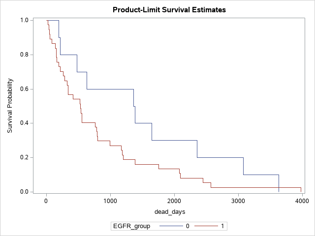

The LIFETEST Procedure

Stratum 1: EGFR_group = 0

| Product-Limit Survival Estimates event_free | Product-Limit Survival Estimates | Product-Limit Survival Estimates Survival | Product-Limit Survival Estimates Failure | Product-Limit Survival Estimates Survival Standard Error | Product-Limit Survival Estimates Number Failed | Product-Limit Survival Estimates Number Left |
| --- | --- | --- | --- | --- | --- | --- |
| 0.00 |  | 1.0000 | 0 | 0 | 0 | 35 |
| 11.00 |  | 0.9714 | 0.0286 | 0.0282 | 1 | 34 |
| 134.00 |  | 0.9429 | 0.0571 | 0.0392 | 2 | 33 |
| 197.00 |  | 0.9143 | 0.0857 | 0.0473 | 3 | 32 |
| 481.00 |  | 0.8857 | 0.1143 | 0.0538 | 4 | 31 |
| 555.00 | * | . | . | . | 4 | 30 |
| 580.00 | * | . | . | . | 4 | 29 |
| 605.00 | * | . | . | . | 4 | 28 |
| 634.00 |  | 0.8541 | 0.1459 | 0.0604 | 5 | 27 |
| 689.00 | * | . | . | . | 5 | 26 |
| 819.00 | * | . | . | . | 5 | 25 |
| 821.00 | * | . | . | . | 5 | 24 |
| 827.00 | * | . | . | . | 5 | 23 |
| 907.00 | * | . | . | . | 5 | 22 |
| 1000.00 | * | . | . | . | 5 | 21 |
| 1019.00 | * | . | . | . | 5 | 20 |
| 1024.00 | * | . | . | . | 5 | 19 |
| 1064.00 | * | . | . | . | 5 | 18 |
| 1361.00 |  | 0.8066 | 0.1934 | 0.0734 | 6 | 17 |
| 1386.00 |  | 0.7592 | 0.2408 | 0.0830 | 7 | 16 |
| 1643.00 |  | 0.7117 | 0.2883 | 0.0904 | 8 | 15 |
| 2024.00 | * | . | . | . | 8 | 14 |
| 2355.00 |  | 0.6609 | 0.3391 | 0.0972 | 9 | 13 |
| 3074.00 |  | 0.6101 | 0.3899 | 0.1021 | 10 | 12 |
| 3358.00 | * | . | . | . | 10 | 11 |
| 3478.00 | * | . | . | . | 10 | 10 |
| 3563.00 | * | . | . | . | 10 | 9 |
| 3633.00 |  | 0.5423 | 0.4577 | 0.1110 | 11 | 8 |
| 3667.00 | * | . | . | . | 11 | 7 |
| 3723.00 | * | . | . | . | 11 | 6 |
| 3786.00 | * | . | . | . | 11 | 5 |
| 3861.00 | * | . | . | . | 11 | 4 |
| 3898.00 | * | . | . | . | 11 | 3 |
| 3991.00 | * | . | . | . | 11 | 2 |
| 3993.00 | * | . | . | . | 11 | 1 |
| 4008.00 | * | . | . | . | 11 | 0 |

Note:The marked survival times are censored observations.

Summary Statistics for Time Variable event_free

| Quartile Estimates Percent | Quartile Estimates Point Estimate | Quartile Estimates 95% Confidence Interval Transform | Quartile Estimates 95% Confidence Interval [Lower | Quartile Estimates 95% Confidence Interval Upper) |
| --- | --- | --- | --- | --- |
| 75 | . | LOGLOG | . | . |
| 50 | . | LOGLOG | 1643.00 | . |
| 25 | 1643.00 | LOGLOG | 481.00 | 3633.00 |

| Mean | Standard Error |
| --- | --- |
| 2744.21 | 252.42 |

Note:The mean survival time and its standard error were underestimated because the largest observation was censored and the estimation was restricted to the largest event time.

The LIFETEST Procedure

Stratum 2: EGFR_group = 1

| Product-Limit Survival Estimates event_free | Product-Limit Survival Estimates | Product-Limit Survival Estimates Survival | Product-Limit Survival Estimates Failure | Product-Limit Survival Estimates Survival Standard Error | Product-Limit Survival Estimates Number Failed | Product-Limit Survival Estimates Number Left |
| --- | --- | --- | --- | --- | --- | --- |
| 0.00 |  | 1.0000 | 0 | 0 | 0 | 70 |
| 2.00 |  | 0.9857 | 0.0143 | 0.0142 | 1 | 69 |
| 6.00 |  | 0.9714 | 0.0286 | 0.0199 | 2 | 68 |
| 10.00 |  | 0.9571 | 0.0429 | 0.0242 | 3 | 67 |
| 16.00 |  | 0.9429 | 0.0571 | 0.0277 | 4 | 66 |
| 21.00 |  | 0.9286 | 0.0714 | 0.0308 | 5 | 65 |
| 22.00 |  | 0.9143 | 0.0857 | 0.0335 | 6 | 64 |
| 37.00 |  | 0.9000 | 0.1000 | 0.0359 | 7 | 63 |
| 46.00 |  | 0.8857 | 0.1143 | 0.0380 | 8 | 62 |
| 53.00 |  | 0.8714 | 0.1286 | 0.0400 | 9 | 61 |
| 86.00 |  | 0.8571 | 0.1429 | 0.0418 | 10 | 60 |
| 137.00 |  | 0.8429 | 0.1571 | 0.0435 | 11 | 59 |
| 152.00 |  | 0.8286 | 0.1714 | 0.0450 | 12 | 58 |
| 153.00 |  | 0.8143 | 0.1857 | 0.0465 | 13 | 57 |
| 161.00 |  | 0.8000 | 0.2000 | 0.0478 | 14 | 56 |
| 197.00 |  | 0.7857 | 0.2143 | 0.0490 | 15 | 55 |
| 220.00 |  | 0.7714 | 0.2286 | 0.0502 | 16 | 54 |
| 259.00 |  | 0.7571 | 0.2429 | 0.0513 | 17 | 53 |
| 286.00 |  | 0.7429 | 0.2571 | 0.0522 | 18 | 52 |
| 322.00 |  | 0.7286 | 0.2714 | 0.0532 | 19 | 51 |
| 337.00 |  | 0.7143 | 0.2857 | 0.0540 | 20 | 50 |
| 342.00 |  | 0.7000 | 0.3000 | 0.0548 | 21 | 49 |
| 416.00 |  | 0.6857 | 0.3143 | 0.0555 | 22 | 48 |
| 502.00 | * | . | . | . | 22 | 47 |
| 526.00 |  | 0.6711 | 0.3289 | 0.0562 | 23 | 46 |
| 528.00 |  | 0.6565 | 0.3435 | 0.0568 | 24 | 45 |
| 539.00 |  | 0.6419 | 0.3581 | 0.0574 | 25 | 44 |
| 551.00 |  | 0.6274 | 0.3726 | 0.0579 | 26 | 43 |
| 555.00 |  | 0.6128 | 0.3872 | 0.0584 | 27 | 42 |
| 586.00 | * | . | . | . | 27 | 41 |
| 679.00 | * | . | . | . | 27 | 40 |
| 762.00 |  | 0.5974 | 0.4026 | 0.0589 | 28 | 39 |
| 783.00 |  | 0.5821 | 0.4179 | 0.0594 | 29 | 38 |
| 793.00 |  | 0.5668 | 0.4332 | 0.0597 | 30 | 37 |
| 804.00 |  | 0.5515 | 0.4485 | 0.0601 | 31 | 36 |
| 846.00 | * | . | . | . | 31 | 35 |
| 847.00 | * | . | . | . | 31 | 34 |
| 862.00 | * | . | . | . | 31 | 33 |
| 870.00 | * | . | . | . | 31 | 32 |
| 875.00 | * | . | . | . | 31 | 31 |
| 883.00 | * | . | . | . | 31 | 30 |
| 887.00 | * | . | . | . | 31 | 29 |
| 895.00 | * | . | . | . | 31 | 28 |
| 903.00 | * | . | . | . | 31 | 27 |
| 906.00 | * | . | . | . | 31 | 26 |
| 943.00 | * | . | . | . | 31 | 25 |
| 954.00 | * | . | . | . | 31 | 24 |
| 964.00 | * | . | . | . | 31 | 23 |
| 972.00 | * | . | . | . | 31 | 22 |
| 973.00 | * | . | . | . | 31 | 21 |
| 992.00 |  | 0.5252 | 0.4748 | 0.0627 | 32 | 20 |
| 1016.00 | * | . | . | . | 32 | 19 |
| 1059.00 | * | . | . | . | 32 | 18 |
| 1159.00 | * | . | . | . | 32 | 17 |
| 1168.00 |  | 0.4943 | 0.5057 | 0.0662 | 33 | 16 |
| 1185.00 |  | 0.4634 | 0.5366 | 0.0689 | 34 | 15 |
| 1198.00 |  | 0.4325 | 0.5675 | 0.0709 | 35 | 14 |
| 1382.00 |  | 0.4016 | 0.5984 | 0.0722 | 36 | 13 |
| 1511.00 |  | 0.3707 | 0.6293 | 0.0730 | 37 | 12 |
| 1754.00 |  | 0.3399 | 0.6601 | 0.0731 | 38 | 11 |
| 2076.00 |  | 0.3090 | 0.6910 | 0.0727 | 39 | 10 |
| 2096.00 |  | 0.2781 | 0.7219 | 0.0717 | 40 | 9 |
| 2573.00 |  | 0.2472 | 0.7528 | 0.0701 | 41 | 8 |
| 3756.00 | * | . | . | . | 41 | 7 |
| 3812.00 | * | . | . | . | 41 | 6 |
| 3892.00 | * | . | . | . | 41 | 5 |
| 3899.00 | * | . | . | . | 41 | 4 |
| 3979.00 |  | 0.1854 | 0.8146 | 0.0750 | 42 | 3 |
| 3999.00 | * | . | . | . | 42 | 2 |
| 3999.00 | * | . | . | . | 42 | 1 |
| 4003.00 | * | . | . | . | 42 | 0 |

Note:The marked survival times are censored observations.

Summary Statistics for Time Variable event_free

| Quartile Estimates Percent | Quartile Estimates Point Estimate | Quartile Estimates 95% Confidence Interval Transform | Quartile Estimates 95% Confidence Interval [Lower | Quartile Estimates 95% Confidence Interval Upper) |
| --- | --- | --- | --- | --- |
| 75 | 2573.00 | LOGLOG | 1511.00 | . |
| 50 | 1168.00 | LOGLOG | 555.00 | 1754.00 |
| 25 | 286.00 | LOGLOG | 137.00 | 539.00 |

| Mean | Standard Error |
| --- | --- |
| 1605.58 | 217.54 |

Note:The mean survival time and its standard error were underestimated because the largest observation was censored and the estimation was restricted to the largest event time.

| Summary of the Number of Censored and Uncensored Values Stratum | Summary of the Number of Censored and Uncensored Values EGFR_group | Summary of the Number of Censored and Uncensored Values Total | Summary of the Number of Censored and Uncensored Values Failed | Summary of the Number of Censored and Uncensored Values Censored | Summary of the Number of Censored and Uncensored Values Percent Censored |
| --- | --- | --- | --- | --- | --- |
| 1 | 0 | 35 | 11 | 24 | 68.57 |
| 2 | 1 | 70 | 42 | 28 | 40.00 |
| Total |  | 105 | 53 | 52 | 49.52 |

Note:5 observations with invalid time, censoring, or strata values were deleted.

The LIFETEST Procedure

Testing Homogeneity of Survival Curves for event_free over Strata

| Rank Statistics EGFR_group | Rank Statistics Log-Rank | Rank Statistics Wilcoxon |
| --- | --- | --- |
| 0 | -11.833 | -823.00 |
| 1 | 11.833 | 823.00 |

| Covariance Matrix for the Log-Rank Statistics EGFR_group | Covariance Matrix for the Log-Rank Statistics 0 | Covariance Matrix for the Log-Rank Statistics 1 |
| --- | --- | --- |
| 0 | 12.5716 | -12.5716 |
| 1 | -12.5716 | 12.5716 |

| Covariance Matrix for the Wilcoxon Statistics EGFR_group | Covariance Matrix for the Wilcoxon Statistics 0 | Covariance Matrix for the Wilcoxon Statistics 1 |
| --- | --- | --- |
| 0 | 66891.0 | -66891.0 |
| 1 | -66891.0 | 66891.0 |

| Test of Equality over Strata Test | Test of Equality over Strata Chi-Square | Test of Equality over Strata DF | Test of Equality over Strata Pr > Chi-Square |
| --- | --- | --- | --- |
| Log-Rank | 11.1370 | 1 | 0.0008 |
| Wilcoxon | 10.1259 | 1 | 0.0015 |
| -2Log(LR) | 16.5097 | 1 | <.0001 |

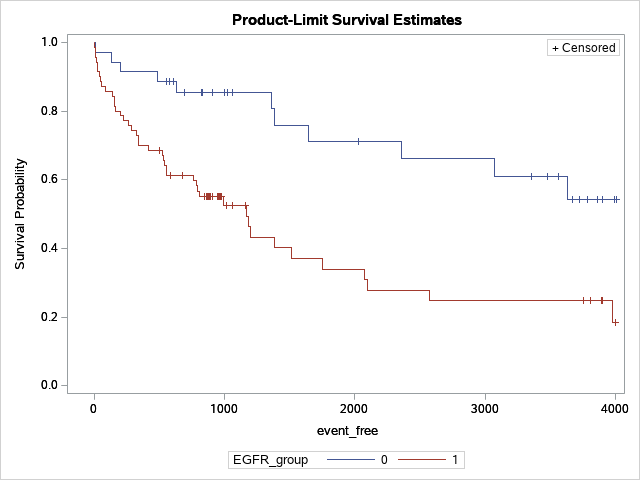

The LIFETEST Procedure

Stratum 1: TBX_group = 0

| Product-Limit Survival Estimates dead_days | Product-Limit Survival Estimates | Product-Limit Survival Estimates Survival | Product-Limit Survival Estimates Failure | Product-Limit Survival Estimates Survival Standard Error | Product-Limit Survival Estimates Number Failed | Product-Limit Survival Estimates Number Left |
| --- | --- | --- | --- | --- | --- | --- |
| 0.00 |  | 1.0000 | 0 | 0 | 0 | 21 |
| 37.00 |  | 0.9524 | 0.0476 | 0.0465 | 1 | 20 |
| 152.00 |  | 0.9048 | 0.0952 | 0.0641 | 2 | 19 |
| 197.00 |  | . | . | . | 3 | 18 |
| 197.00 |  | 0.8095 | 0.1905 | 0.0857 | 4 | 17 |
| 219.00 |  | 0.7619 | 0.2381 | 0.0929 | 5 | 16 |
| 259.00 |  | 0.7143 | 0.2857 | 0.0986 | 6 | 15 |
| 286.00 |  | 0.6667 | 0.3333 | 0.1029 | 7 | 14 |
| 416.00 |  | 0.6190 | 0.3810 | 0.1060 | 8 | 13 |
| 481.00 |  | 0.5714 | 0.4286 | 0.1080 | 9 | 12 |
| 539.00 |  | 0.5238 | 0.4762 | 0.1090 | 10 | 11 |
| 634.00 |  | 0.4762 | 0.5238 | 0.1090 | 11 | 10 |
| 783.00 |  | 0.4286 | 0.5714 | 0.1080 | 12 | 9 |
| 1198.00 |  | 0.3810 | 0.6190 | 0.1060 | 13 | 8 |
| 1361.00 |  | 0.3333 | 0.6667 | 0.1029 | 14 | 7 |
| 1386.00 |  | 0.2857 | 0.7143 | 0.0986 | 15 | 6 |
| 1643.00 |  | 0.2381 | 0.7619 | 0.0929 | 16 | 5 |
| 2096.00 |  | 0.1905 | 0.8095 | 0.0857 | 17 | 4 |
| 2355.00 |  | 0.1429 | 0.8571 | 0.0764 | 18 | 3 |
| 2445.00 |  | 0.0952 | 0.9048 | 0.0641 | 19 | 2 |
| 3074.00 |  | 0.0476 | 0.9524 | 0.0465 | 20 | 1 |
| 3633.00 |  | 0 | 1.0000 | . | 21 | 0 |

Summary Statistics for Time Variable dead_days

| Quartile Estimates Percent | Quartile Estimates Point Estimate | Quartile Estimates 95% Confidence Interval Transform | Quartile Estimates 95% Confidence Interval [Lower | Quartile Estimates 95% Confidence Interval Upper) |
| --- | --- | --- | --- | --- |
| 75 | 1643.00 | LOGLOG | 783.00 | 3074.00 |
| 50 | 634.00 | LOGLOG | 259.00 | 1386.00 |
| 25 | 259.00 | LOGLOG | 37.00 | 481.00 |

| Mean | Standard Error |
| --- | --- |
| 1113.86 | 231.08 |

The LIFETEST Procedure

Stratum 2: TBX_group = 1

| Product-Limit Survival Estimates dead_days | Product-Limit Survival Estimates | Product-Limit Survival Estimates Survival | Product-Limit Survival Estimates Failure | Product-Limit Survival Estimates Survival Standard Error | Product-Limit Survival Estimates Number Failed | Product-Limit Survival Estimates Number Left |
| --- | --- | --- | --- | --- | --- | --- |
| 0.00 |  | 1.0000 | 0 | 0 | 0 | 26 |
| 22.00 |  | 0.9615 | 0.0385 | 0.0377 | 1 | 25 |
| 46.00 |  | 0.9231 | 0.0769 | 0.0523 | 2 | 24 |
| 53.00 |  | 0.8846 | 0.1154 | 0.0627 | 3 | 23 |
| 86.00 |  | 0.8462 | 0.1538 | 0.0708 | 4 | 22 |
| 137.00 |  | 0.8077 | 0.1923 | 0.0773 | 5 | 21 |
| 153.00 |  | 0.7692 | 0.2308 | 0.0826 | 6 | 20 |
| 161.00 |  | 0.7308 | 0.2692 | 0.0870 | 7 | 19 |
| 220.00 |  | 0.6923 | 0.3077 | 0.0905 | 8 | 18 |
| 322.00 |  | 0.6538 | 0.3462 | 0.0933 | 9 | 17 |
| 337.00 |  | 0.6154 | 0.3846 | 0.0954 | 10 | 16 |
| 342.00 |  | 0.5769 | 0.4231 | 0.0969 | 11 | 15 |
| 526.00 |  | 0.5385 | 0.4615 | 0.0978 | 12 | 14 |
| 528.00 |  | 0.5000 | 0.5000 | 0.0981 | 13 | 13 |
| 551.00 |  | 0.4615 | 0.5385 | 0.0978 | 14 | 12 |
| 555.00 |  | 0.4231 | 0.5769 | 0.0969 | 15 | 11 |
| 762.00 |  | 0.3846 | 0.6154 | 0.0954 | 16 | 10 |
| 793.00 |  | 0.3462 | 0.6538 | 0.0933 | 17 | 9 |
| 804.00 |  | 0.3077 | 0.6923 | 0.0905 | 18 | 8 |
| 992.00 |  | 0.2692 | 0.7308 | 0.0870 | 19 | 7 |
| 1168.00 |  | 0.2308 | 0.7692 | 0.0826 | 20 | 6 |
| 1185.00 |  | 0.1923 | 0.8077 | 0.0773 | 21 | 5 |
| 1382.00 |  | 0.1538 | 0.8462 | 0.0708 | 22 | 4 |
| 1754.00 |  | 0.1154 | 0.8846 | 0.0627 | 23 | 3 |
| 2076.00 |  | 0.0769 | 0.9231 | 0.0523 | 24 | 2 |
| 2573.00 |  | 0.0385 | 0.9615 | 0.0377 | 25 | 1 |
| 3979.00 |  | 0 | 1.0000 | . | 26 | 0 |

Summary Statistics for Time Variable dead_days

| Quartile Estimates Percent | Quartile Estimates Point Estimate | Quartile Estimates 95% Confidence Interval Transform | Quartile Estimates 95% Confidence Interval [Lower | Quartile Estimates 95% Confidence Interval Upper) |
| --- | --- | --- | --- | --- |
| 75 | 1168.00 | LOGLOG | 555.00 | 2076.00 |
| 50 | 539.50 | LOGLOG | 220.00 | 804.00 |
| 25 | 161.00 | LOGLOG | 46.00 | 342.00 |

| Mean | Standard Error |
| --- | --- |
| 827.19 | 180.59 |

| Summary of the Number of Censored and Uncensored Values Stratum | Summary of the Number of Censored and Uncensored Values TBX_group | Summary of the Number of Censored and Uncensored Values Total | Summary of the Number of Censored and Uncensored Values Failed | Summary of the Number of Censored and Uncensored Values Censored | Summary of the Number of Censored and Uncensored Values Percent Censored |
| --- | --- | --- | --- | --- | --- |
| 1 | 0 | 21 | 21 | 0 | 0.00 |
| 2 | 1 | 26 | 26 | 0 | 0.00 |
| Total |  | 47 | 47 | 0 | 0.00 |

The LIFETEST Procedure

Testing Homogeneity of Survival Curves for dead_days over Strata

| Rank Statistics TBX_group | Rank Statistics Log-Rank | Rank Statistics Wilcoxon |
| --- | --- | --- |
| 0 | -2.7214 | -88.000 |
| 1 | 2.7214 | 88.000 |

| Covariance Matrix for the Log-Rank Statistics TBX_group | Covariance Matrix for the Log-Rank Statistics 0 | Covariance Matrix for the Log-Rank Statistics 1 |
| --- | --- | --- |
| 0 | 11.2368 | -11.2368 |
| 1 | -11.2368 | 11.2368 |

| Covariance Matrix for the Wilcoxon Statistics TBX_group | Covariance Matrix for the Wilcoxon Statistics 0 | Covariance Matrix for the Wilcoxon Statistics 1 |
| --- | --- | --- |
| 0 | 8864.49 | -8864.49 |
| 1 | -8864.49 | 8864.49 |

| Test of Equality over Strata Test | Test of Equality over Strata Chi-Square | Test of Equality over Strata DF | Test of Equality over Strata Pr > Chi-Square |
| --- | --- | --- | --- |
| Log-Rank | 0.6591 | 1 | 0.4169 |
| Wilcoxon | 0.8736 | 1 | 0.3500 |
| -2Log(LR) | 1.0356 | 1 | 0.3088 |

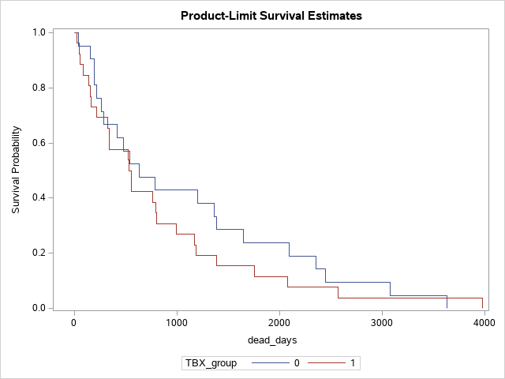

| RMST Analysis Information |  |
| --- | --- |
| Tau | 3633 |

| RMST Estimates Stratum | RMST Estimates TBX_group | RMST Estimates Estimate | RMST Estimates Standard Error |
| --- | --- | --- | --- |
| 1 | 0 | 1113.857 | 225.5157 |
| 2 | 1 | 813.8846 | 168.2298 |

| RMST Test of Equality Source | RMST Test of Equality Chi-Square | RMST Test of Equality DF | RMST Test of Equality Pr > ChiSq |
| --- | --- | --- | --- |
| Strata | 1.1367 | 1 | 0.2863 |

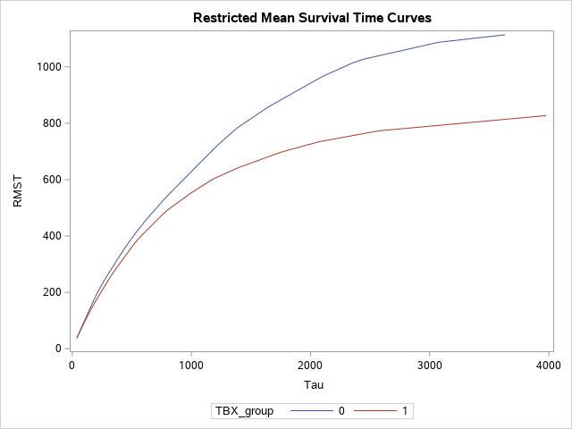

The LIFETEST Procedure

Stratum 1: TBX_group = 0

| Product-Limit Survival Estimates event_free | Product-Limit Survival Estimates | Product-Limit Survival Estimates Survival | Product-Limit Survival Estimates Failure | Product-Limit Survival Estimates Survival Standard Error | Product-Limit Survival Estimates Number Failed | Product-Limit Survival Estimates Number Left |
| --- | --- | --- | --- | --- | --- | --- |
| 0.00 |  | 1.0000 | 0 | 0 | 0 | 57 |
| 10.00 |  | 0.9825 | 0.0175 | 0.0174 | 1 | 56 |
| 11.00 |  | 0.9649 | 0.0351 | 0.0244 | 2 | 55 |
| 16.00 |  | 0.9474 | 0.0526 | 0.0296 | 3 | 54 |
| 37.00 |  | 0.9298 | 0.0702 | 0.0338 | 4 | 53 |
| 134.00 |  | 0.9123 | 0.0877 | 0.0375 | 5 | 52 |
| 152.00 |  | 0.8947 | 0.1053 | 0.0406 | 6 | 51 |
| 197.00 |  | . | . | . | 7 | 50 |
| 197.00 |  | 0.8596 | 0.1404 | 0.0460 | 8 | 49 |
| 259.00 |  | 0.8421 | 0.1579 | 0.0483 | 9 | 48 |
| 286.00 |  | 0.8246 | 0.1754 | 0.0504 | 10 | 47 |
| 416.00 |  | 0.8070 | 0.1930 | 0.0523 | 11 | 46 |
| 481.00 |  | 0.7895 | 0.2105 | 0.0540 | 12 | 45 |
| 539.00 |  | 0.7719 | 0.2281 | 0.0556 | 13 | 44 |
| 555.00 | * | . | . | . | 13 | 43 |
| 580.00 | * | . | . | . | 13 | 42 |
| 605.00 | * | . | . | . | 13 | 41 |
| 634.00 |  | 0.7531 | 0.2469 | 0.0573 | 14 | 40 |
| 689.00 | * | . | . | . | 14 | 39 |
| 783.00 |  | 0.7338 | 0.2662 | 0.0590 | 15 | 38 |
| 819.00 | * | . | . | . | 15 | 37 |
| 821.00 | * | . | . | . | 15 | 36 |
| 827.00 | * | . | . | . | 15 | 35 |
| 846.00 | * | . | . | . | 15 | 34 |
| 862.00 | * | . | . | . | 15 | 33 |
| 887.00 | * | . | . | . | 15 | 32 |
| 906.00 | * | . | . | . | 15 | 31 |
| 907.00 | * | . | . | . | 15 | 30 |
| 943.00 | * | . | . | . | 15 | 29 |
| 954.00 | * | . | . | . | 15 | 28 |
| 964.00 | * | . | . | . | 15 | 27 |
| 973.00 | * | . | . | . | 15 | 26 |
| 1000.00 | * | . | . | . | 15 | 25 |
| 1019.00 | * | . | . | . | 15 | 24 |
| 1024.00 | * | . | . | . | 15 | 23 |
| 1059.00 | * | . | . | . | 15 | 22 |
| 1064.00 | * | . | . | . | 15 | 21 |
| 1159.00 | * | . | . | . | 15 | 20 |
| 1198.00 |  | 0.6971 | 0.3029 | 0.0665 | 16 | 19 |
| 1361.00 |  | 0.6604 | 0.3396 | 0.0724 | 17 | 18 |
| 1386.00 |  | 0.6237 | 0.3763 | 0.0771 | 18 | 17 |
| 1511.00 |  | 0.5870 | 0.4130 | 0.0808 | 19 | 16 |
| 1643.00 |  | 0.5503 | 0.4497 | 0.0837 | 20 | 15 |
| 2024.00 | * | . | . | . | 20 | 14 |
| 2096.00 |  | 0.5110 | 0.4890 | 0.0865 | 21 | 13 |
| 2355.00 |  | 0.4717 | 0.5283 | 0.0883 | 22 | 12 |
| 3074.00 |  | 0.4324 | 0.5676 | 0.0893 | 23 | 11 |
| 3358.00 | * | . | . | . | 23 | 10 |
| 3478.00 | * | . | . | . | 23 | 9 |
| 3563.00 | * | . | . | . | 23 | 8 |
| 3633.00 |  | 0.3784 | 0.6216 | 0.0930 | 24 | 7 |
| 3723.00 | * | . | . | . | 24 | 6 |
| 3786.00 | * | . | . | . | 24 | 5 |
| 3861.00 | * | . | . | . | 24 | 4 |
| 3898.00 | * | . | . | . | 24 | 3 |
| 3991.00 | * | . | . | . | 24 | 2 |
| 3993.00 | * | . | . | . | 24 | 1 |
| 4008.00 | * | . | . | . | 24 | 0 |

Note:The marked survival times are censored observations.

Summary Statistics for Time Variable event_free

| Quartile Estimates Percent | Quartile Estimates Point Estimate | Quartile Estimates 95% Confidence Interval Transform | Quartile Estimates 95% Confidence Interval [Lower | Quartile Estimates 95% Confidence Interval Upper) |
| --- | --- | --- | --- | --- |
| 75 | . | LOGLOG | 3633.00 | . |
| 50 | 2355.00 | LOGLOG | 1361.00 | . |
| 25 | 783.00 | LOGLOG | 197.00 | 1511.00 |

| Mean | Standard Error |
| --- | --- |
| 2202.27 | 226.55 |

Note:The mean survival time and its standard error were underestimated because the largest observation was censored and the estimation was restricted to the largest event time.

The LIFETEST Procedure

Stratum 2: TBX_group = 1

| Product-Limit Survival Estimates event_free | Product-Limit Survival Estimates | Product-Limit Survival Estimates Survival | Product-Limit Survival Estimates Failure | Product-Limit Survival Estimates Survival Standard Error | Product-Limit Survival Estimates Number Failed | Product-Limit Survival Estimates Number Left |
| --- | --- | --- | --- | --- | --- | --- |
| 0.00 |  | 1.0000 | 0 | 0 | 0 | 48 |
| 2.00 |  | 0.9792 | 0.0208 | 0.0206 | 1 | 47 |
| 6.00 |  | 0.9583 | 0.0417 | 0.0288 | 2 | 46 |
| 21.00 |  | 0.9375 | 0.0625 | 0.0349 | 3 | 45 |
| 22.00 |  | 0.9167 | 0.0833 | 0.0399 | 4 | 44 |
| 46.00 |  | 0.8958 | 0.1042 | 0.0441 | 5 | 43 |
| 53.00 |  | 0.8750 | 0.1250 | 0.0477 | 6 | 42 |
| 86.00 |  | 0.8542 | 0.1458 | 0.0509 | 7 | 41 |
| 137.00 |  | 0.8333 | 0.1667 | 0.0538 | 8 | 40 |
| 153.00 |  | 0.8125 | 0.1875 | 0.0563 | 9 | 39 |
| 161.00 |  | 0.7917 | 0.2083 | 0.0586 | 10 | 38 |
| 220.00 |  | 0.7708 | 0.2292 | 0.0607 | 11 | 37 |
| 322.00 |  | 0.7500 | 0.2500 | 0.0625 | 12 | 36 |
| 337.00 |  | 0.7292 | 0.2708 | 0.0641 | 13 | 35 |
| 342.00 |  | 0.7083 | 0.2917 | 0.0656 | 14 | 34 |
| 502.00 | * | . | . | . | 14 | 33 |
| 526.00 |  | 0.6869 | 0.3131 | 0.0670 | 15 | 32 |
| 528.00 |  | 0.6654 | 0.3346 | 0.0683 | 16 | 31 |
| 551.00 |  | 0.6439 | 0.3561 | 0.0694 | 17 | 30 |
| 555.00 |  | 0.6225 | 0.3775 | 0.0703 | 18 | 29 |
| 586.00 | * | . | . | . | 18 | 28 |
| 679.00 | * | . | . | . | 18 | 27 |
| 762.00 |  | 0.5994 | 0.4006 | 0.0714 | 19 | 26 |
| 793.00 |  | 0.5764 | 0.4236 | 0.0723 | 20 | 25 |
| 804.00 |  | 0.5533 | 0.4467 | 0.0730 | 21 | 24 |
| 847.00 | * | . | . | . | 21 | 23 |
| 870.00 | * | . | . | . | 21 | 22 |
| 875.00 | * | . | . | . | 21 | 21 |
| 883.00 | * | . | . | . | 21 | 20 |
| 895.00 | * | . | . | . | 21 | 19 |
| 903.00 | * | . | . | . | 21 | 18 |
| 972.00 | * | . | . | . | 21 | 17 |
| 992.00 |  | 0.5208 | 0.4792 | 0.0756 | 22 | 16 |
| 1016.00 | * | . | . | . | 22 | 15 |
| 1168.00 |  | 0.4860 | 0.5140 | 0.0781 | 23 | 14 |
| 1185.00 |  | 0.4513 | 0.5487 | 0.0799 | 24 | 13 |
| 1382.00 |  | 0.4166 | 0.5834 | 0.0809 | 25 | 12 |
| 1754.00 |  | 0.3819 | 0.6181 | 0.0813 | 26 | 11 |
| 2076.00 |  | 0.3472 | 0.6528 | 0.0810 | 27 | 10 |
| 2573.00 |  | 0.3125 | 0.6875 | 0.0800 | 28 | 9 |
| 3667.00 | * | . | . | . | 28 | 8 |
| 3756.00 | * | . | . | . | 28 | 7 |
| 3812.00 | * | . | . | . | 28 | 6 |
| 3892.00 | * | . | . | . | 28 | 5 |
| 3899.00 | * | . | . | . | 28 | 4 |
| 3979.00 |  | 0.2343 | 0.7657 | 0.0904 | 29 | 3 |
| 3999.00 | * | . | . | . | 29 | 2 |
| 3999.00 | * | . | . | . | 29 | 1 |
| 4003.00 | * | . | . | . | 29 | 0 |

Note:The marked survival times are censored observations.

Summary Statistics for Time Variable event_free

| Quartile Estimates Percent | Quartile Estimates Point Estimate | Quartile Estimates 95% Confidence Interval Transform | Quartile Estimates 95% Confidence Interval [Lower | Quartile Estimates 95% Confidence Interval Upper) |
| --- | --- | --- | --- | --- |
| 75 | 3979.00 | LOGLOG | 1754.00 | . |
| 50 | 1168.00 | LOGLOG | 551.00 | 2573.00 |
| 25 | 329.50 | LOGLOG | 53.00 | 555.00 |

| Mean | Standard Error |
| --- | --- |
| 1768.02 | 261.40 |

Note:The mean survival time and its standard error were underestimated because the largest observation was censored and the estimation was restricted to the largest event time.

| Summary of the Number of Censored and Uncensored Values Stratum | Summary of the Number of Censored and Uncensored Values TBX_group | Summary of the Number of Censored and Uncensored Values Total | Summary of the Number of Censored and Uncensored Values Failed | Summary of the Number of Censored and Uncensored Values Censored | Summary of the Number of Censored and Uncensored Values Percent Censored |
| --- | --- | --- | --- | --- | --- |
| 1 | 0 | 57 | 24 | 33 | 57.89 |
| 2 | 1 | 48 | 29 | 19 | 39.58 |
| Total |  | 105 | 53 | 52 | 49.52 |

The LIFETEST Procedure

Testing Homogeneity of Survival Curves for event_free over Strata

| Rank Statistics TBX_group | Rank Statistics Log-Rank | Rank Statistics Wilcoxon |
| --- | --- | --- |
| 0 | -6.0433 | -480.00 |
| 1 | 6.0433 | 480.00 |

| Covariance Matrix for the Log-Rank Statistics TBX_group | Covariance Matrix for the Log-Rank Statistics 0 | Covariance Matrix for the Log-Rank Statistics 1 |
| --- | --- | --- |
| 0 | 12.9611 | -12.9611 |
| 1 | -12.9611 | 12.9611 |

| Covariance Matrix for the Wilcoxon Statistics TBX_group | Covariance Matrix for the Wilcoxon Statistics 0 | Covariance Matrix for the Wilcoxon Statistics 1 |
| --- | --- | --- |
| 0 | 70653.0 | -70653.0 |
| 1 | -70653.0 | 70653.0 |

| Test of Equality over Strata Test | Test of Equality over Strata Chi-Square | Test of Equality over Strata DF | Test of Equality over Strata Pr > Chi-Square |
| --- | --- | --- | --- |
| Log-Rank | 2.8178 | 1 | 0.0932 |
| Wilcoxon | 3.2610 | 1 | 0.0709 |
| -2Log(LR) | 2.9173 | 1 | 0.0876 |

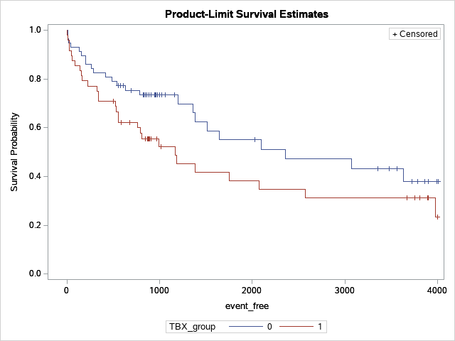

| RMST Analysis Information |  |
| --- | --- |
| Tau | 4003 |

| RMST Estimates Stratum | RMST Estimates TBX_group | RMST Estimates Estimate | RMST Estimates Standard Error |
| --- | --- | --- | --- |
| 1 | 0 | 2342.259 | 248.1111 |
| 2 | 1 | 1773.648 | 258.1975 |

| RMST Test of Equality Source | RMST Test of Equality Chi-Square | RMST Test of Equality DF | RMST Test of Equality Pr > ChiSq |
| --- | --- | --- | --- |
| Strata | 2.5215 | 1 | 0.1123 |

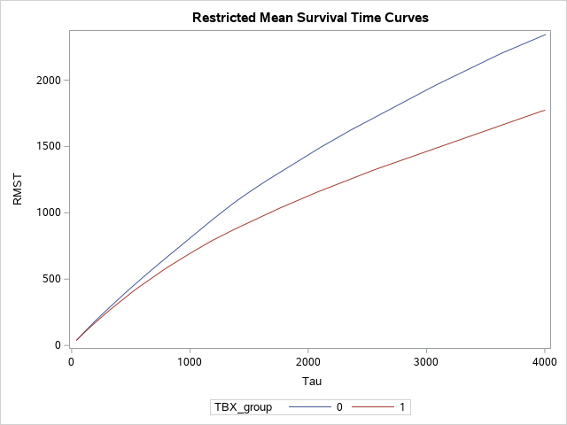

The LIFETEST Procedure

Stratum 1: EGFR_group = 0

| Product-Limit Survival Estimates dead_days | Product-Limit Survival Estimates | Product-Limit Survival Estimates Survival | Product-Limit Survival Estimates Failure | Product-Limit Survival Estimates Survival Standard Error | Product-Limit Survival Estimates Number Failed | Product-Limit Survival Estimates Number Left |
| --- | --- | --- | --- | --- | --- | --- |
| 0.00 |  | 1.0000 | 0 | 0 | 0 | 10 |
| 197.00 |  | 0.9000 | 0.1000 | 0.0949 | 1 | 9 |
| 219.00 |  | 0.8000 | 0.2000 | 0.1265 | 2 | 8 |
| 481.00 |  | 0.7000 | 0.3000 | 0.1449 | 3 | 7 |
| 634.00 |  | 0.6000 | 0.4000 | 0.1549 | 4 | 6 |
| 1361.00 |  | 0.5000 | 0.5000 | 0.1581 | 5 | 5 |
| 1386.00 |  | 0.4000 | 0.6000 | 0.1549 | 6 | 4 |
| 1643.00 |  | 0.3000 | 0.7000 | 0.1449 | 7 | 3 |
| 2355.00 |  | 0.2000 | 0.8000 | 0.1265 | 8 | 2 |
| 3074.00 |  | 0.1000 | 0.9000 | 0.0949 | 9 | 1 |
| 3633.00 |  | 0 | 1.0000 | . | 10 | 0 |

Summary Statistics for Time Variable dead_days

| Quartile Estimates Percent | Quartile Estimates Point Estimate | Quartile Estimates 95% Confidence Interval Transform | Quartile Estimates 95% Confidence Interval [Lower | Quartile Estimates 95% Confidence Interval Upper) |
| --- | --- | --- | --- | --- |
| 75 | 2355.00 | LOGLOG | 1361.00 | . |
| 50 | 1373.50 | LOGLOG | 197.00 | 2355.00 |
| 25 | 481.00 | LOGLOG | 197.00 | 1386.00 |

| Mean | Standard Error |
| --- | --- |
| 1498.30 | 379.15 |

The LIFETEST Procedure

Stratum 2: EGFR_group = 1

| Product-Limit Survival Estimates dead_days | Product-Limit Survival Estimates | Product-Limit Survival Estimates Survival | Product-Limit Survival Estimates Failure | Product-Limit Survival Estimates Survival Standard Error | Product-Limit Survival Estimates Number Failed | Product-Limit Survival Estimates Number Left |
| --- | --- | --- | --- | --- | --- | --- |
| 0.00 |  | 1.0000 | 0 | 0 | 0 | 37 |
| 22.00 |  | 0.9730 | 0.0270 | 0.0267 | 1 | 36 |
| 37.00 |  | 0.9459 | 0.0541 | 0.0372 | 2 | 35 |
| 46.00 |  | 0.9189 | 0.0811 | 0.0449 | 3 | 34 |
| 53.00 |  | 0.8919 | 0.1081 | 0.0510 | 4 | 33 |
| 86.00 |  | 0.8649 | 0.1351 | 0.0562 | 5 | 32 |
| 137.00 |  | 0.8378 | 0.1622 | 0.0606 | 6 | 31 |
| 152.00 |  | 0.8108 | 0.1892 | 0.0644 | 7 | 30 |
| 153.00 |  | 0.7838 | 0.2162 | 0.0677 | 8 | 29 |
| 161.00 |  | 0.7568 | 0.2432 | 0.0705 | 9 | 28 |
| 197.00 |  | 0.7297 | 0.2703 | 0.0730 | 10 | 27 |
| 220.00 |  | 0.7027 | 0.2973 | 0.0751 | 11 | 26 |
| 259.00 |  | 0.6757 | 0.3243 | 0.0770 | 12 | 25 |
| 286.00 |  | 0.6486 | 0.3514 | 0.0785 | 13 | 24 |
| 322.00 |  | 0.6216 | 0.3784 | 0.0797 | 14 | 23 |
| 337.00 |  | 0.5946 | 0.4054 | 0.0807 | 15 | 22 |
| 342.00 |  | 0.5676 | 0.4324 | 0.0814 | 16 | 21 |
| 416.00 |  | 0.5405 | 0.4595 | 0.0819 | 17 | 20 |
| 526.00 |  | 0.5135 | 0.4865 | 0.0822 | 18 | 19 |
| 528.00 |  | 0.4865 | 0.5135 | 0.0822 | 19 | 18 |
| 539.00 |  | 0.4595 | 0.5405 | 0.0819 | 20 | 17 |
| 551.00 |  | 0.4324 | 0.5676 | 0.0814 | 21 | 16 |
| 555.00 |  | 0.4054 | 0.5946 | 0.0807 | 22 | 15 |
| 762.00 |  | 0.3784 | 0.6216 | 0.0797 | 23 | 14 |
| 783.00 |  | 0.3514 | 0.6486 | 0.0785 | 24 | 13 |
| 793.00 |  | 0.3243 | 0.6757 | 0.0770 | 25 | 12 |
| 804.00 |  | 0.2973 | 0.7027 | 0.0751 | 26 | 11 |
| 992.00 |  | 0.2703 | 0.7297 | 0.0730 | 27 | 10 |
| 1168.00 |  | 0.2432 | 0.7568 | 0.0705 | 28 | 9 |
| 1185.00 |  | 0.2162 | 0.7838 | 0.0677 | 29 | 8 |
| 1198.00 |  | 0.1892 | 0.8108 | 0.0644 | 30 | 7 |
| 1382.00 |  | 0.1622 | 0.8378 | 0.0606 | 31 | 6 |
| 1754.00 |  | 0.1351 | 0.8649 | 0.0562 | 32 | 5 |
| 2076.00 |  | 0.1081 | 0.8919 | 0.0510 | 33 | 4 |
| 2096.00 |  | 0.0811 | 0.9189 | 0.0449 | 34 | 3 |
| 2445.00 |  | 0.0541 | 0.9459 | 0.0372 | 35 | 2 |
| 2573.00 |  | 0.0270 | 0.9730 | 0.0267 | 36 | 1 |
| 3979.00 |  | 0 | 1.0000 | . | 37 | 0 |

Summary Statistics for Time Variable dead_days

| Quartile Estimates Percent | Quartile Estimates Point Estimate | Quartile Estimates 95% Confidence Interval Transform | Quartile Estimates 95% Confidence Interval [Lower | Quartile Estimates 95% Confidence Interval Upper) |
| --- | --- | --- | --- | --- |
| 75 | 1168.00 | LOGLOG | 555.00 | 2076.00 |
| 50 | 528.00 | LOGLOG | 286.00 | 793.00 |
| 25 | 197.00 | LOGLOG | 53.00 | 337.00 |

| Mean | Standard Error |
| --- | --- |
| 808.51 | 144.72 |

| Summary of the Number of Censored and Uncensored Values Stratum | Summary of the Number of Censored and Uncensored Values EGFR_group | Summary of the Number of Censored and Uncensored Values Total | Summary of the Number of Censored and Uncensored Values Failed | Summary of the Number of Censored and Uncensored Values Censored | Summary of the Number of Censored and Uncensored Values Percent Censored |
| --- | --- | --- | --- | --- | --- |
| 1 | 0 | 10 | 10 | 0 | 0.00 |
| 2 | 1 | 37 | 37 | 0 | 0.00 |
| Total |  | 47 | 47 | 0 | 0.00 |

The LIFETEST Procedure

Testing Homogeneity of Survival Curves for dead_days over Strata

| Rank Statistics EGFR_group | Rank Statistics Log-Rank | Rank Statistics Wilcoxon |
| --- | --- | --- |
| 0 | -4.8699 | -143.00 |
| 1 | 4.8699 | 143.00 |

| Covariance Matrix for the Log-Rank Statistics EGFR_group | Covariance Matrix for the Log-Rank Statistics 0 | Covariance Matrix for the Log-Rank Statistics 1 |
| --- | --- | --- |
| 0 | 9.61055 | -9.61055 |
| 1 | -9.61055 | 9.61055 |

| Covariance Matrix for the Wilcoxon Statistics EGFR_group | Covariance Matrix for the Wilcoxon Statistics 0 | Covariance Matrix for the Wilcoxon Statistics 1 |
| --- | --- | --- |
| 0 | 6746.86 | -6746.86 |
| 1 | -6746.86 | 6746.86 |

| Test of Equality over Strata Test | Test of Equality over Strata Chi-Square | Test of Equality over Strata DF | Test of Equality over Strata Pr > Chi-Square |
| --- | --- | --- | --- |
| Log-Rank | 2.4677 | 1 | 0.1162 |
| Wilcoxon | 3.0309 | 1 | 0.0817 |
| -2Log(LR) | 3.3418 | 1 | 0.0675 |

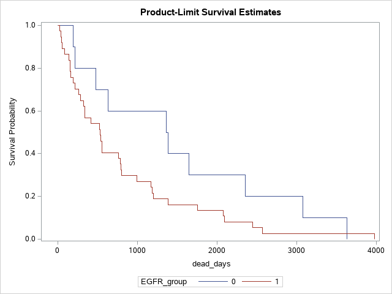

| RMST Analysis Information |  |
| --- | --- |
| Tau | 3633 |

| RMST Estimates Stratum | RMST Estimates EGFR_group | RMST Estimates Estimate | RMST Estimates Standard Error |
| --- | --- | --- | --- |
| 1 | 0 | 1498.300 | 359.6945 |
| 2 | 1 | 799.1622 | 137.3311 |

| RMST Test of Equality Source | RMST Test of Equality Chi-Square | RMST Test of Equality DF | RMST Test of Equality Pr > ChiSq |
| --- | --- | --- | --- |
| Strata | 3.2973 | 1 | 0.0694 |

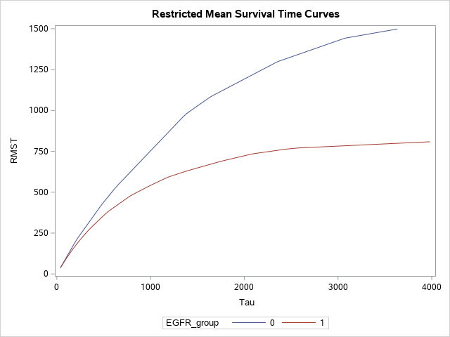

The LIFETEST Procedure

Stratum 1: EGFR_group = 0

| Product-Limit Survival Estimates event_free | Product-Limit Survival Estimates | Product-Limit Survival Estimates Survival | Product-Limit Survival Estimates Failure | Product-Limit Survival Estimates Survival Standard Error | Product-Limit Survival Estimates Number Failed | Product-Limit Survival Estimates Number Left |
| --- | --- | --- | --- | --- | --- | --- |
| 0.00 |  | 1.0000 | 0 | 0 | 0 | 35 |
| 11.00 |  | 0.9714 | 0.0286 | 0.0282 | 1 | 34 |
| 134.00 |  | 0.9429 | 0.0571 | 0.0392 | 2 | 33 |
| 197.00 |  | 0.9143 | 0.0857 | 0.0473 | 3 | 32 |
| 481.00 |  | 0.8857 | 0.1143 | 0.0538 | 4 | 31 |
| 555.00 | * | . | . | . | 4 | 30 |
| 580.00 | * | . | . | . | 4 | 29 |
| 605.00 | * | . | . | . | 4 | 28 |
| 634.00 |  | 0.8541 | 0.1459 | 0.0604 | 5 | 27 |
| 689.00 | * | . | . | . | 5 | 26 |
| 819.00 | * | . | . | . | 5 | 25 |
| 821.00 | * | . | . | . | 5 | 24 |
| 827.00 | * | . | . | . | 5 | 23 |
| 907.00 | * | . | . | . | 5 | 22 |
| 1000.00 | * | . | . | . | 5 | 21 |
| 1019.00 | * | . | . | . | 5 | 20 |
| 1024.00 | * | . | . | . | 5 | 19 |
| 1064.00 | * | . | . | . | 5 | 18 |
| 1361.00 |  | 0.8066 | 0.1934 | 0.0734 | 6 | 17 |
| 1386.00 |  | 0.7592 | 0.2408 | 0.0830 | 7 | 16 |
| 1643.00 |  | 0.7117 | 0.2883 | 0.0904 | 8 | 15 |
| 2024.00 | * | . | . | . | 8 | 14 |
| 2355.00 |  | 0.6609 | 0.3391 | 0.0972 | 9 | 13 |
| 3074.00 |  | 0.6101 | 0.3899 | 0.1021 | 10 | 12 |
| 3358.00 | * | . | . | . | 10 | 11 |
| 3478.00 | * | . | . | . | 10 | 10 |
| 3563.00 | * | . | . | . | 10 | 9 |
| 3633.00 |  | 0.5423 | 0.4577 | 0.1110 | 11 | 8 |
| 3667.00 | * | . | . | . | 11 | 7 |
| 3723.00 | * | . | . | . | 11 | 6 |
| 3786.00 | * | . | . | . | 11 | 5 |
| 3861.00 | * | . | . | . | 11 | 4 |
| 3898.00 | * | . | . | . | 11 | 3 |
| 3991.00 | * | . | . | . | 11 | 2 |
| 3993.00 | * | . | . | . | 11 | 1 |
| 4008.00 | * | . | . | . | 11 | 0 |

Note:The marked survival times are censored observations.

Summary Statistics for Time Variable event_free

| Quartile Estimates Percent | Quartile Estimates Point Estimate | Quartile Estimates 95% Confidence Interval Transform | Quartile Estimates 95% Confidence Interval [Lower | Quartile Estimates 95% Confidence Interval Upper) |
| --- | --- | --- | --- | --- |
| 75 | . | LOGLOG | . | . |
| 50 | . | LOGLOG | 1643.00 | . |
| 25 | 1643.00 | LOGLOG | 481.00 | 3633.00 |

| Mean | Standard Error |
| --- | --- |
| 2744.21 | 252.42 |

Note:The mean survival time and its standard error were underestimated because the largest observation was censored and the estimation was restricted to the largest event time.

The LIFETEST Procedure

Stratum 2: EGFR_group = 1

| Product-Limit Survival Estimates event_free | Product-Limit Survival Estimates | Product-Limit Survival Estimates Survival | Product-Limit Survival Estimates Failure | Product-Limit Survival Estimates Survival Standard Error | Product-Limit Survival Estimates Number Failed | Product-Limit Survival Estimates Number Left |
| --- | --- | --- | --- | --- | --- | --- |
| 0.00 |  | 1.0000 | 0 | 0 | 0 | 70 |
| 2.00 |  | 0.9857 | 0.0143 | 0.0142 | 1 | 69 |
| 6.00 |  | 0.9714 | 0.0286 | 0.0199 | 2 | 68 |
| 10.00 |  | 0.9571 | 0.0429 | 0.0242 | 3 | 67 |
| 16.00 |  | 0.9429 | 0.0571 | 0.0277 | 4 | 66 |
| 21.00 |  | 0.9286 | 0.0714 | 0.0308 | 5 | 65 |
| 22.00 |  | 0.9143 | 0.0857 | 0.0335 | 6 | 64 |
| 37.00 |  | 0.9000 | 0.1000 | 0.0359 | 7 | 63 |
| 46.00 |  | 0.8857 | 0.1143 | 0.0380 | 8 | 62 |
| 53.00 |  | 0.8714 | 0.1286 | 0.0400 | 9 | 61 |
| 86.00 |  | 0.8571 | 0.1429 | 0.0418 | 10 | 60 |
| 137.00 |  | 0.8429 | 0.1571 | 0.0435 | 11 | 59 |
| 152.00 |  | 0.8286 | 0.1714 | 0.0450 | 12 | 58 |
| 153.00 |  | 0.8143 | 0.1857 | 0.0465 | 13 | 57 |
| 161.00 |  | 0.8000 | 0.2000 | 0.0478 | 14 | 56 |
| 197.00 |  | 0.7857 | 0.2143 | 0.0490 | 15 | 55 |
| 220.00 |  | 0.7714 | 0.2286 | 0.0502 | 16 | 54 |
| 259.00 |  | 0.7571 | 0.2429 | 0.0513 | 17 | 53 |
| 286.00 |  | 0.7429 | 0.2571 | 0.0522 | 18 | 52 |
| 322.00 |  | 0.7286 | 0.2714 | 0.0532 | 19 | 51 |
| 337.00 |  | 0.7143 | 0.2857 | 0.0540 | 20 | 50 |
| 342.00 |  | 0.7000 | 0.3000 | 0.0548 | 21 | 49 |
| 416.00 |  | 0.6857 | 0.3143 | 0.0555 | 22 | 48 |
| 502.00 | * | . | . | . | 22 | 47 |
| 526.00 |  | 0.6711 | 0.3289 | 0.0562 | 23 | 46 |
| 528.00 |  | 0.6565 | 0.3435 | 0.0568 | 24 | 45 |
| 539.00 |  | 0.6419 | 0.3581 | 0.0574 | 25 | 44 |
| 551.00 |  | 0.6274 | 0.3726 | 0.0579 | 26 | 43 |
| 555.00 |  | 0.6128 | 0.3872 | 0.0584 | 27 | 42 |
| 586.00 | * | . | . | . | 27 | 41 |
| 679.00 | * | . | . | . | 27 | 40 |
| 762.00 |  | 0.5974 | 0.4026 | 0.0589 | 28 | 39 |
| 783.00 |  | 0.5821 | 0.4179 | 0.0594 | 29 | 38 |
| 793.00 |  | 0.5668 | 0.4332 | 0.0597 | 30 | 37 |
| 804.00 |  | 0.5515 | 0.4485 | 0.0601 | 31 | 36 |
| 846.00 | * | . | . | . | 31 | 35 |
| 847.00 | * | . | . | . | 31 | 34 |
| 862.00 | * | . | . | . | 31 | 33 |
| 870.00 | * | . | . | . | 31 | 32 |
| 875.00 | * | . | . | . | 31 | 31 |
| 883.00 | * | . | . | . | 31 | 30 |
| 887.00 | * | . | . | . | 31 | 29 |
| 895.00 | * | . | . | . | 31 | 28 |
| 903.00 | * | . | . | . | 31 | 27 |
| 906.00 | * | . | . | . | 31 | 26 |
| 943.00 | * | . | . | . | 31 | 25 |
| 954.00 | * | . | . | . | 31 | 24 |
| 964.00 | * | . | . | . | 31 | 23 |
| 972.00 | * | . | . | . | 31 | 22 |
| 973.00 | * | . | . | . | 31 | 21 |
| 992.00 |  | 0.5252 | 0.4748 | 0.0627 | 32 | 20 |
| 1016.00 | * | . | . | . | 32 | 19 |
| 1059.00 | * | . | . | . | 32 | 18 |
| 1159.00 | * | . | . | . | 32 | 17 |
| 1168.00 |  | 0.4943 | 0.5057 | 0.0662 | 33 | 16 |
| 1185.00 |  | 0.4634 | 0.5366 | 0.0689 | 34 | 15 |
| 1198.00 |  | 0.4325 | 0.5675 | 0.0709 | 35 | 14 |
| 1382.00 |  | 0.4016 | 0.5984 | 0.0722 | 36 | 13 |
| 1511.00 |  | 0.3707 | 0.6293 | 0.0730 | 37 | 12 |
| 1754.00 |  | 0.3399 | 0.6601 | 0.0731 | 38 | 11 |
| 2076.00 |  | 0.3090 | 0.6910 | 0.0727 | 39 | 10 |
| 2096.00 |  | 0.2781 | 0.7219 | 0.0717 | 40 | 9 |
| 2573.00 |  | 0.2472 | 0.7528 | 0.0701 | 41 | 8 |
| 3756.00 | * | . | . | . | 41 | 7 |
| 3812.00 | * | . | . | . | 41 | 6 |
| 3892.00 | * | . | . | . | 41 | 5 |
| 3899.00 | * | . | . | . | 41 | 4 |
| 3979.00 |  | 0.1854 | 0.8146 | 0.0750 | 42 | 3 |
| 3999.00 | * | . | . | . | 42 | 2 |
| 3999.00 | * | . | . | . | 42 | 1 |
| 4003.00 | * | . | . | . | 42 | 0 |

Note:The marked survival times are censored observations.

Summary Statistics for Time Variable event_free

| Quartile Estimates Percent | Quartile Estimates Point Estimate | Quartile Estimates 95% Confidence Interval Transform | Quartile Estimates 95% Confidence Interval [Lower | Quartile Estimates 95% Confidence Interval Upper) |
| --- | --- | --- | --- | --- |
| 75 | 2573.00 | LOGLOG | 1511.00 | . |
| 50 | 1168.00 | LOGLOG | 555.00 | 1754.00 |
| 25 | 286.00 | LOGLOG | 137.00 | 539.00 |

| Mean | Standard Error |
| --- | --- |
| 1605.58 | 217.54 |

Note:The mean survival time and its standard error were underestimated because the largest observation was censored and the estimation was restricted to the largest event time.

| Summary of the Number of Censored and Uncensored Values Stratum | Summary of the Number of Censored and Uncensored Values EGFR_group | Summary of the Number of Censored and Uncensored Values Total | Summary of the Number of Censored and Uncensored Values Failed | Summary of the Number of Censored and Uncensored Values Censored | Summary of the Number of Censored and Uncensored Values Percent Censored |
| --- | --- | --- | --- | --- | --- |
| 1 | 0 | 35 | 11 | 24 | 68.57 |
| 2 | 1 | 70 | 42 | 28 | 40.00 |
| Total |  | 105 | 53 | 52 | 49.52 |

The LIFETEST Procedure

Testing Homogeneity of Survival Curves for event_free over Strata

| Rank Statistics EGFR_group | Rank Statistics Log-Rank | Rank Statistics Wilcoxon |
| --- | --- | --- |
| 0 | -11.833 | -823.00 |
| 1 | 11.833 | 823.00 |

| Covariance Matrix for the Log-Rank Statistics EGFR_group | Covariance Matrix for the Log-Rank Statistics 0 | Covariance Matrix for the Log-Rank Statistics 1 |
| --- | --- | --- |
| 0 | 12.5716 | -12.5716 |
| 1 | -12.5716 | 12.5716 |

| Covariance Matrix for the Wilcoxon Statistics EGFR_group | Covariance Matrix for the Wilcoxon Statistics 0 | Covariance Matrix for the Wilcoxon Statistics 1 |
| --- | --- | --- |
| 0 | 66891.0 | -66891.0 |
| 1 | -66891.0 | 66891.0 |

| Test of Equality over Strata Test | Test of Equality over Strata Chi-Square | Test of Equality over Strata DF | Test of Equality over Strata Pr > Chi-Square |
| --- | --- | --- | --- |
| Log-Rank | 11.1370 | 1 | 0.0008 |
| Wilcoxon | 10.1259 | 1 | 0.0015 |
| -2Log(LR) | 16.5097 | 1 | <.0001 |

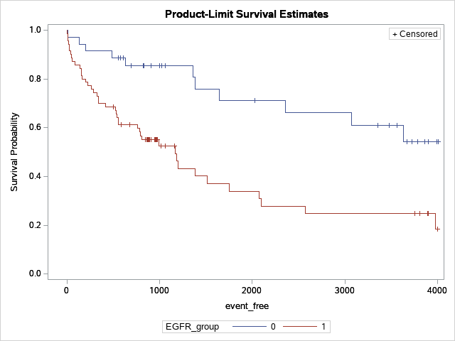

| RMST Analysis Information |  |
| --- | --- |
| Tau | 4003 |

| RMST Estimates Stratum | RMST Estimates EGFR_group | RMST Estimates Estimate | RMST Estimates Standard Error |
| --- | --- | --- | --- |
| 1 | 0 | 2944.854 | 271.3996 |
| 2 | 1 | 1610.031 | 216.0922 |

| RMST Test of Equality Source | RMST Test of Equality Chi-Square | RMST Test of Equality DF | RMST Test of Equality Pr > ChiSq |
| --- | --- | --- | --- |
| Strata | 14.8043 | 1 | 0.0001 |

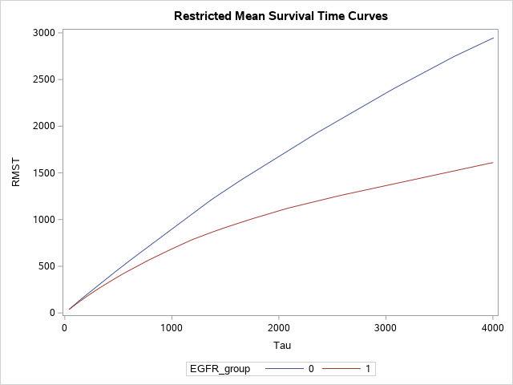